# DFI_1_Analysis

```python
# initiation
import warnings
import arviz as az
import matplotlib.pyplot as plt
import numpy as np
import pandas as pd
import seaborn as sns
import constrNMPy
import os


from matplotlib import gridspec
from scipy import sparse, special, stats

%config InlineBackend.figure_format = 'retina'
warnings.simplefilter(action="ignore", category=FutureWarning)

# addpath
# os.chdir('/Users/abel/Desktop/Project DFI/Exp2_data/DFI_2_Analysis/tables') # change the working directory to the folder where the data is stored

# color pallette
[gr,ye,re,bl,pu,ir,ak] = ['#8ECFC9', '#FFBE7A', '#FA7F6F', '#82B0D2','#BEB8DC', '#E7DAD2','#999999']

# set the style of the plots
az.style.use("arviz-white")

# set the font
from matplotlib.font_manager import FontProperties

plt.rcParams['font.size'] = 15
plt.rcParams['axes.labelsize'] = 15
plt.rcParams['xtick.labelsize'] = 10
plt.rcParams['ytick.labelsize'] = 10
plt.rcParams['axes.titlesize'] = 18
plt.rcParams['axes.titleweight'] = 'bold'
plt.rcParams['legend.fontsize'] = 10
plt.rcParams['legend.title_fontsize'] = 12
plt.rcParams['legend.loc'] = 'lower right'  # 'upper right', 'upper left', 'lower left', 'lower right', 'right'
plt.rcParams['axes.titlelocation'] = 'left'  # 'left', 'center', 'right'
plt.rcParams['axes.titley'] = 1.05  # 根据需要调整y的位置
plt.rcParams['axes.edgecolor'] = 'black'
plt.rcParams['axes.linewidth'] = 1
plt.rcParams['ytick.left'] = True
```

```python
# 从db文件中读取变量和先前数据
import dill
dill.load_session('DFI_1_Data.db')
```

### Fig1 各个Inducer条件下的Target正确率与反应时

数据提取

```python
use_num = 9

T1_acc = np.zeros((use_num,3))
T2_acc = np.zeros((use_num,3))
T1_num = np.zeros((use_num,3))
T2_num = np.zeros((use_num,3))
T1_RT = np.zeros((use_num,3))
T2_RT = np.zeros((use_num,3))

for i in range(1,use_num+1):
    id = i
    currentdata = pd.read_excel('DFI_1_Data.xlsx',sheet_name='Sheet'+str(id))
    dt = currentdata.copy()

    T1B0 = dt[(dt['TargetNum'] == 1) & (dt['InducerNum'] == 0)]
    T1B1 = dt[(dt['TargetNum'] == 1) & (dt['InducerNum'] == 1)]
    T1B2 = dt[(dt['TargetNum'] == 1) & (dt['InducerNum'] == 2)]

    T2B0 = dt[(dt['TargetNum'] == 2) & (dt['InducerNum'] == 0)]
    T2B1 = dt[(dt['TargetNum'] == 2) & (dt['InducerNum'] == 1)]
    T2B2 = dt[(dt['TargetNum'] == 2) & (dt['InducerNum'] == 2)]

    T1_acc[i-1,:] = [T1B0['mean_RespAcc'].mean(),T1B1['mean_RespAcc'].mean(),T1B2['mean_RespAcc'].mean()]
    T2_acc[i-1,:] = [T2B0['mean_RespAcc'].mean(),T2B1['mean_RespAcc'].mean(),T2B2['mean_RespAcc'].mean()]
    T1_RT[i-1,:] = [T1B0['mean_RT'].mean()-0.15,T1B1['mean_RT'].mean(),T1B2['mean_RT'].mean()]
    T2_RT[i-1,:] = [T2B0['mean_RT'].mean(),T2B1['mean_RT'].mean(),T2B2['mean_RT'].mean()]


T1_num = T1_acc * 1 + (1-T1_acc) * 2
T2_num = T2_acc * 2 + (1-T2_acc) * 1
```

Exp 1 Accuracy 小提琴图

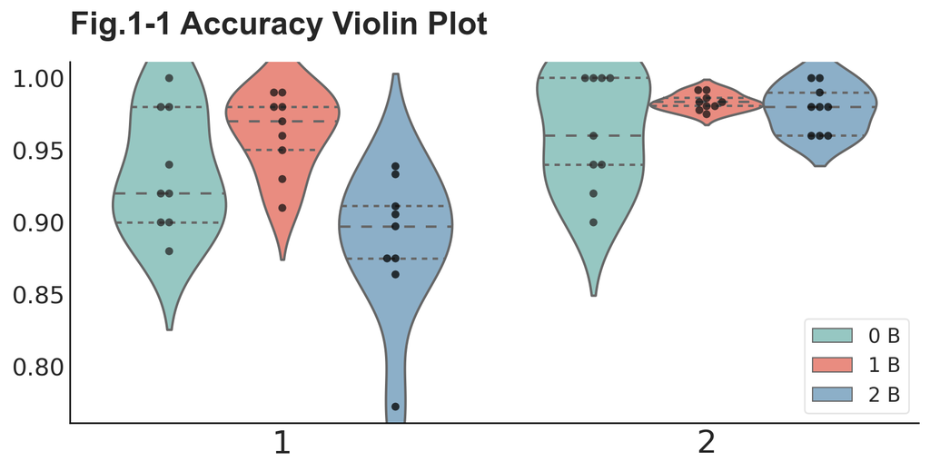

```python
data1 = T1_acc
data2 = T2_acc
df1 = pd.DataFrame(data1, columns=['0 B', '1 B', '2 B'])
df1['Target'] = '1 F'
df2 = pd.DataFrame(data2, columns=['0 B', '1 B', '2 B'])
df2['Target'] = '2 F'
df = pd.concat([df1, df2])
df_melted = df.melt(id_vars='Target', var_name='Beep', value_name='Accuracy')

plt.figure(figsize=(8,4))
plt.axes_edgecolor = 'black'
sns.violinplot(x='Target', y='Accuracy', hue='Beep', data=df_melted, inner='quartile', palette=[gr, re, bl], scale='width')
legend = plt.legend(loc='lower right', title='', fontsize='large', frameon=True, framealpha=0.5, fancybox=True)
sns.swarmplot(x='Target', y='Accuracy', hue='Beep', data=df_melted, color='k',alpha = 0.75, size=5, dodge=True, legend=False)
plt.legend(loc='lower right', title='', fontsize='small', frameon=True, framealpha=0.5, fancybox=True)
plt.xlabel('')
plt.xticks([0,1],['1','2'],fontsize=20)
plt.yticks(fontsize = 15)
plt.ylabel('')
plt.title('Fig.1-1 Accuracy Violin Plot', fontsize=20, fontweight='bold', y=1.05, fontfamily='Arial')
plt.show()
```

#### （导出数据为csv文件）

导出实验一中，不同Target和Inducer下的反应准确率均值为 "Exp_1_1.csv"

后续使用JASP进行统计检验分析

```python
import numpy as np

# create an array of subject numbers
subjects = np.arange(1, 10)
# replicate the array 6 times
subjects_repeated = np.tile(subjects, 6)
df_melted['Subjects'] = subjects_repeated
df_pivot = df_melted.pivot(columns=['Target', 'Beep'], values='Accuracy', index='Subjects')
df_pivot.reset_index(inplace=True)
df_pivot.columns = df_pivot.columns.map('{0[0]}{0[1]}'.format)
# df_pivot.to_csv('Exp_1_1.csv', index=False)
df_pivot.head()
```

|  | Subjects | 1 F0 B | 2 F0 B | 1 F1 B | 2 F1 B | 1 F2 B | 2 F2 B |
| --- | --- | --- | --- | --- | --- | --- | --- |
| 0 | 1 | 0.94 | 0.94 | 0.91 | 0.977778 | 0.772222 | 1.00 |
| 1 | 2 | 0.90 | 1.00 | 0.97 | 0.980556 | 0.875000 | 0.98 |
| 2 | 3 | 0.92 | 0.92 | 0.98 | 0.991667 | 0.933333 | 0.98 |
| 3 | 4 | 1.00 | 0.94 | 0.99 | 0.975000 | 0.938889 | 0.96 |
| 4 | 5 | 0.98 | 1.00 | 0.95 | 0.983333 | 0.905556 | 0.96 |

Exp 1 RT 小提琴图

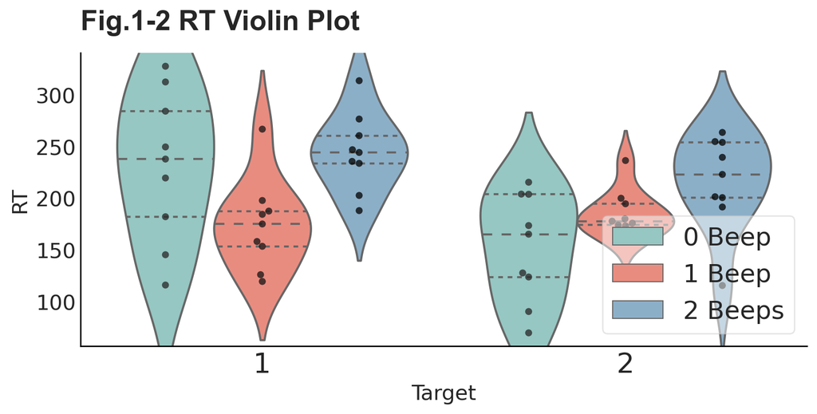

```python
data1 = T1_RT * 1000
data2 = T2_RT * 1000
df1 = pd.DataFrame(data1, columns=['0 Beep', '1 Beep', '2 Beeps'])
df1['Target'] = '1 Flash'
df2 = pd.DataFrame(data2, columns=['0 Beep', '1 Beep', '2 Beeps'])
df2['Target'] = '2 Flashes'
df = pd.concat([df1, df2])
df_melted = df.melt(id_vars='Target', var_name='Beep', value_name='RT')

plt.figure(figsize=(8,4))
plt.axes_edgecolor = 'black'
sns.violinplot(x='Target', y='RT', hue='Beep', data=df_melted, inner='quartile', palette=[gr, re, bl], scale='width')
legend = plt.legend(title='', fontsize='large', frameon=True, framealpha=0.5, fancybox=True)
sns.swarmplot(x='Target', y='RT', hue='Beep', data=df_melted, color='k',alpha = 0.75, size=5, dodge=True, legend=False)
plt.xticks([0,1],['1','2'],fontsize=20)
plt.yticks(fontsize = 15)
plt.title('Fig.1-2 RT Violin Plot', fontsize=20, fontweight='bold', y=1.05, fontfamily='Arial')
plt.show()
```

合并两张图画在一起

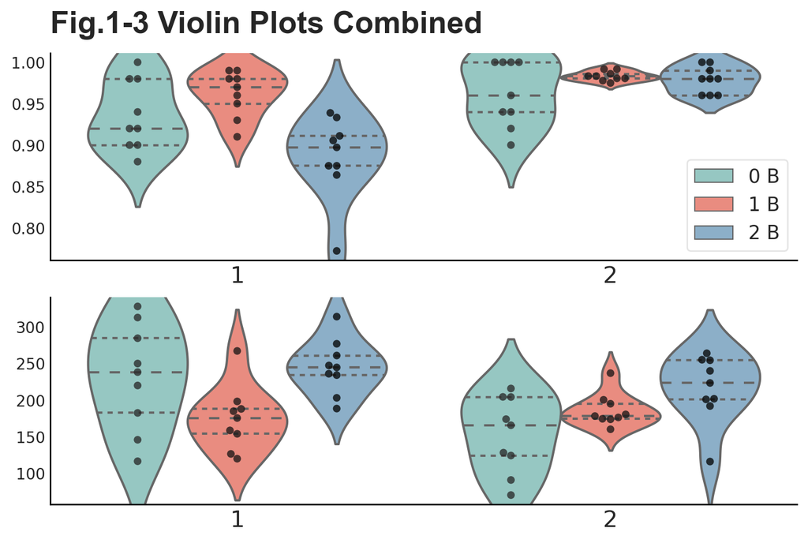

```python
data1 = T1_acc
data2 = T2_acc
df1 = pd.DataFrame(data1, columns=['0 B', '1 B', '2 B'])
df1['Target'] = '1 F'
df2 = pd.DataFrame(data2, columns=['0 B', '1 B', '2 B'])
df2['Target'] = '2 F'
df = pd.concat([df1, df2])
df_melted = df.melt(id_vars='Target', var_name='Beep', value_name='Accuracy')

plt.subplot(2,1,1)
plt.axes_edgecolor = 'black'
sns.violinplot(x='Target', y='Accuracy', hue='Beep', data=df_melted, inner='quartile', palette=[gr, re, bl], scale='width')
legend = plt.legend(loc='lower right', title='', fontsize='large', frameon=True, framealpha=0.5, fancybox=True)
sns.swarmplot(x='Target', y='Accuracy', hue='Beep', data=df_melted, color='k',alpha = 0.75, size=5, dodge=True, legend=False)
plt.legend(loc='lower right', title='', fontsize='small', frameon=True, framealpha=0.5, fancybox=True)
plt.xlabel('')
plt.xticks([0,1],['1','2'],fontsize=15)
plt.title('Fig.1-3 Violin Plots Combined', fontsize=20, fontweight='bold', y=1.05, fontfamily='Arial')
plt.ylabel('')

plt.subplot(2,1,2)
data1 = T1_RT * 1000
data2 = T2_RT * 1000
df1 = pd.DataFrame(data1, columns=['0 Beep', '1 Beep', '2 Beeps'])
df1['Target'] = '1 Flash'
df2 = pd.DataFrame(data2, columns=['0 Beep', '1 Beep', '2 Beeps'])
df2['Target'] = '2 Flashes'
df = pd.concat([df1, df2])
df_melted = df.melt(id_vars='Target', var_name='Beep', value_name='RT')

plt.axes_edgecolor = 'black'
sns.violinplot(x='Target', y='RT', hue='Beep', data=df_melted, inner='quartile', palette=[gr, re, bl], scale='width')
# legend = plt.legend(loc='upper right', title='', fontsize='large', frameon=True, framealpha=0.5, fancybox=True)
plt.legend([],[], frameon=False)
sns.swarmplot(x='Target', y='RT', hue='Beep', data=df_melted, color='k',alpha = 0.75, size=5, dodge=True, legend=False)
plt.xlabel('')
plt.xticks([0,1],['1','2'],fontsize=15)
plt.ylabel('')
plt.show()
```

### Fig2 Effect of eccentricity on target accuracy and reaction time

比较不同条件下知觉的正确率，寻找Eccentricity Effect

- 首先可以看出，离心率本身对视觉感知有一定的影响，在没有听觉干扰物时，para-periphery出现了一定的偏侧化效应；
- 但是在引入了听觉刺激之后，这种偏侧化消失了，进而产生了整体的，离心率越大，正确率越低的效应；
- 对于target = 2，则出现较为奇特的，中心正确率最低，反应时最长的现象。

```python
use_num = 9

T1B0_ecc = np.zeros((use_num, 5))
T1B1_ecc = np.zeros((use_num, 5))
T1B2_ecc = np.zeros((use_num, 5))
T2B0_ecc = np.zeros((use_num, 5))
T2B1_ecc = np.zeros((use_num, 5))
T2B2_ecc = np.zeros((use_num, 5))

T1B0_ecc_RT = np.zeros((use_num, 5))
T1B1_ecc_RT = np.zeros((use_num, 5))
T1B2_ecc_RT = np.zeros((use_num, 5))
T2B0_ecc_RT = np.zeros((use_num, 5))
T2B1_ecc_RT = np.zeros((use_num, 5))
T2B2_ecc_RT = np.zeros((use_num, 5))


for i in range(1, use_num+1):
    id = i
    currentdata = pd.read_excel('DFI_1_Data.xlsx',sheet_name='Sheet'+str(id))
    dt = currentdata.copy()

    T1B0 = dt[(dt['TargetNum'] == 1) & (dt['InducerNum'] == 0)]
    T1B1 = dt[(dt['TargetNum'] == 1) & (dt['InducerNum'] == 1)]
    T1B2 = dt[(dt['TargetNum'] == 1) & (dt['InducerNum'] == 2)]

    T1B0_ecc[i-1,:] = T1B0['mean_RespAcc'].values
    T1B1_ecc[i-1,:] = T1B1['mean_RespAcc'].values
    T1B0_ecc_RT[i-1,:] = T1B0['mean_RT'].values
    T1B1_ecc_RT[i-1,:] = T1B1['mean_RT'].values

    T2B2 = dt[(dt['TargetNum'] == 2) & (dt['InducerNum'] == 2)]
    T2B2_ecc[i-1,:] = T2B2['mean_RespAcc'].values
    T2B2_ecc_RT[i-1,:] = T2B2['mean_RT'].values

    for j in range(5):
        T1B2_ecc[i-1,j] = np.mean(T1B2[T1B2['TargetPos'] == j+1]['mean_RespAcc'].values)
        T2B1_ecc[i-1,j] = np.mean(T2B1[T2B1['TargetPos'] == j+1]['mean_RespAcc'].values)
        T2B0_ecc[i-1,j] = np.mean(T2B0[T2B0['TargetPos'] == j+1]['mean_RespAcc'].values)

        T1B2_ecc_RT[i-1,j] = np.mean(T1B2[T1B2['TargetPos'] == j+1]['mean_RT'].values)
        T2B1_ecc_RT[i-1,j] = np.mean(T2B1[T2B1['TargetPos'] == j+1]['mean_RT'].values)
        T2B0_ecc_RT[i-1,j] = np.mean(T2B0[T2B0['TargetPos'] == j+1]['mean_RT'].values)
```

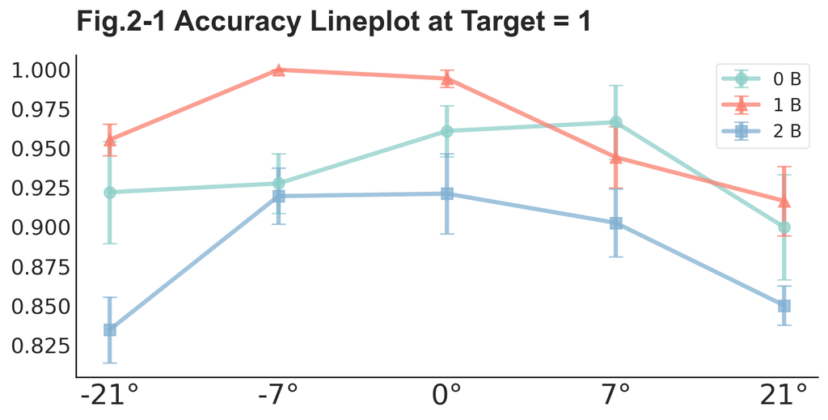

```python
## Draw plots at Target = 1

import numpy as np
import matplotlib.pyplot as plt
from scipy.stats import sem


data1 = T1B0_ecc
data2 = T1B1_ecc
data3 = T1B2_ecc


x = np.arange(1, 6)
mean1 = np.mean(data1, axis=0)
stderr1 = sem(data1, axis=0)

mean2 = np.mean(data2, axis=0)
stderr2 = sem(data2, axis=0)

mean3 = np.mean(data3, axis=0)
stderr3 = sem(data3, axis=0)
plt.figure(figsize=(8,4))
plt.errorbar(x, mean1, yerr=stderr1, fmt='-o', label='0 B', capsize=5, color = gr, alpha = 0.75, linewidth = 3, markersize = 8)
plt.errorbar(x, mean2, yerr=stderr2, fmt='-^', label='1 B', capsize=5, color = re, alpha = 0.75, linewidth = 3, markersize = 8)
plt.errorbar(x, mean3, yerr=stderr3, fmt='-s', label='2 B', capsize=5, color = bl, alpha = 0.75, linewidth = 3, markersize = 8)
plt.xlabel('')
plt.ylabel('')
plt.xticks(x, ['-21°', '-7°', '0°', '7°', '21°'], fontsize=20)
plt.yticks(fontsize = 15)
plt.legend(loc='upper right', title='', fontsize='small', frameon=True, framealpha=0.5, fancybox=True)
plt.title('Fig.2-1 Accuracy Lineplot at Target = 1', fontsize=20, fontweight='bold', y=1.05, fontfamily='Arial')
plt.show()
```

#### （导出数据为csv文件）

导出实验一中，Target = 1时，不同Inducer和离心度下的反应准确率均值为 "Exp_1_2.csv"

后续使用JASP进行统计检验分析

```python
data1 = T1B0_ecc
data2 = T1B1_ecc
data3 = T1B2_ecc
df1 = pd.DataFrame(data1, columns=['1', '2', '3', '4', '5'])
df1['Beep'] = '0'
df2 = pd.DataFrame(data2, columns=['1', '2', '3', '4', '5'])
df2['Beep'] = '1'
df3 = pd.DataFrame(data3, columns=['1', '2', '3', '4', '5'])
df3['Beep'] = '2'
df = pd.concat([df1, df2, df3])
df_melted = df.melt(id_vars='Beep', var_name='Eccentricity', value_name='Accuracy')


# create an array of subject numbers
subjects = np.arange(1, use_num+1)

# replicate the array 6 times
subjects_repeated = np.tile(subjects, 15)

df_melted['Subjects'] = subjects_repeated
df_pivot = df_melted.pivot(columns=['Eccentricity','Beep'], values='Accuracy', index='Subjects')
df_pivot.columns = df_pivot.columns.map('{0[0]}_{0[1]}'.format)
# df_pivot.to_csv('Exp_1_2.csv', index=False)
df_pivot.head()
```

| Subjects | 1_0 | 1_1 | 1_2 | 2_0 | 2_1 | 2_2 | 3_0 | 3_1 | 3_2 | 4_0 | 4_1 | 4_2 | 5_0 | 5_1 | 5_2 |
| --- | --- | --- | --- | --- | --- | --- | --- | --- | --- | --- | --- | --- | --- | --- | --- |
| 1 | 0.8 | 0.90 | 0.708333 | 0.9 | 1.0 | 0.805556 | 1.0 | 0.95 | 0.763889 | 1.0 | 0.85 | 0.777778 | 1.0 | 0.85 | 0.805556 |
| 2 | 0.8 | 0.95 | 0.777778 | 1.0 | 1.0 | 0.916667 | 0.9 | 1.00 | 0.972222 | 1.0 | 0.95 | 0.916667 | 0.8 | 0.95 | 0.791667 |
| 3 | 1.0 | 0.95 | 0.888889 | 0.9 | 1.0 | 0.958333 | 1.0 | 1.00 | 1.000000 | 0.9 | 0.95 | 0.958333 | 0.8 | 1.00 | 0.861111 |
| 4 | 1.0 | 1.00 | 0.902778 | 1.0 | 1.0 | 0.930556 | 1.0 | 1.00 | 0.972222 | 1.0 | 1.00 | 0.972222 | 1.0 | 0.95 | 0.916667 |
| 5 | 1.0 | 0.95 | 0.888889 | 0.9 | 1.0 | 0.972222 | 1.0 | 1.00 | 0.902778 | 1.0 | 0.95 | 0.916667 | 1.0 | 0.85 | 0.847222 |

## （进行左右视野的合并，并进行比较。）

## - 比较的结果在JASP中，左右视野的差异并不显著。

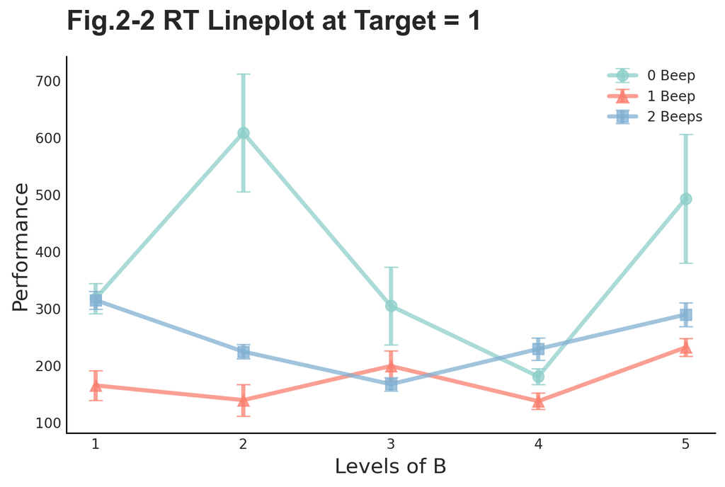

```python
## Draw plots at Target = 1

import numpy as np
import matplotlib.pyplot as plt
from scipy.stats import sem


data1 = T1B0_ecc_RT * 1000
data2 = T1B1_ecc_RT * 1000
data3 = T1B2_ecc_RT * 1000


x = np.arange(1, 6)
mean1 = np.mean(data1, axis=0)
stderr1 = sem(data1, axis=0)

mean2 = np.mean(data2, axis=0)
stderr2 = sem(data2, axis=0)

mean3 = np.mean(data3, axis=0)
stderr3 = sem(data3, axis=0)
plt.errorbar(x, mean1, yerr=stderr1, fmt='-o', label='0 Beep', capsize=5, color = gr, alpha = 0.75, linewidth = 3, markersize = 8)
plt.errorbar(x, mean2, yerr=stderr2, fmt='-^', label='1 Beep', capsize=5, color = re, alpha = 0.75, linewidth = 3, markersize = 8)
plt.errorbar(x, mean3, yerr=stderr3, fmt='-s', label='2 Beeps', capsize=5, color = bl, alpha = 0.75, linewidth = 3, markersize = 8)
plt.title('Fig.2-2 RT Lineplot at Target = 1', fontsize=20, fontweight='bold', y=1.05, fontfamily='Arial')
plt.xlabel('Levels of B')
plt.ylabel('Performance')
plt.xticks(x)
plt.legend(loc='best')
plt.show()
```

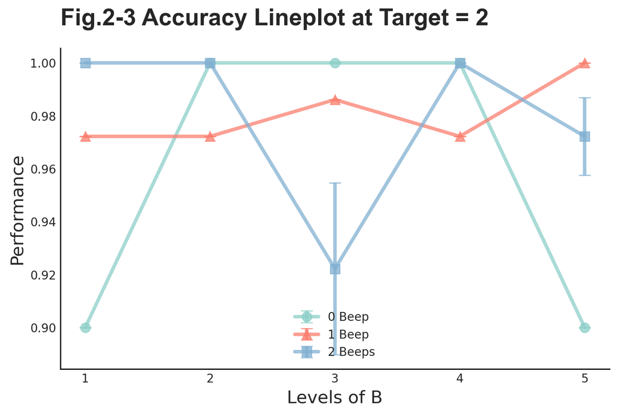

```python
## Draw plots at Target = 2

data1 = T2B0_ecc
data2 = T2B1_ecc
data3 = T2B2_ecc


x = np.arange(1, 6)
mean1 = np.mean(data1, axis=0)
stderr1 = sem(data1, axis=0)

mean2 = np.mean(data2, axis=0)
stderr2 = sem(data2, axis=0)

mean3 = np.mean(data3, axis=0)
stderr3 = sem(data3, axis=0)
plt.errorbar(x, mean1, yerr=stderr1, fmt='-o', label='0 Beep', capsize=5, color = gr, alpha = 0.75, linewidth = 3, markersize = 8)
plt.errorbar(x, mean2, yerr=stderr2, fmt='-^', label='1 Beep', capsize=5, color = re, alpha = 0.75, linewidth = 3, markersize = 8)
plt.errorbar(x, mean3, yerr=stderr3, fmt='-s', label='2 Beeps', capsize=5, color = bl, alpha = 0.75, linewidth = 3, markersize = 8)
plt.title('Fig.2-3 Accuracy Lineplot at Target = 2', fontsize=20, fontweight='bold', y=1.05, fontfamily='Arial')
plt.xlabel('Levels of B')
plt.ylabel('Performance')
plt.xticks(x)
plt.legend(loc='best')
plt.show()
```

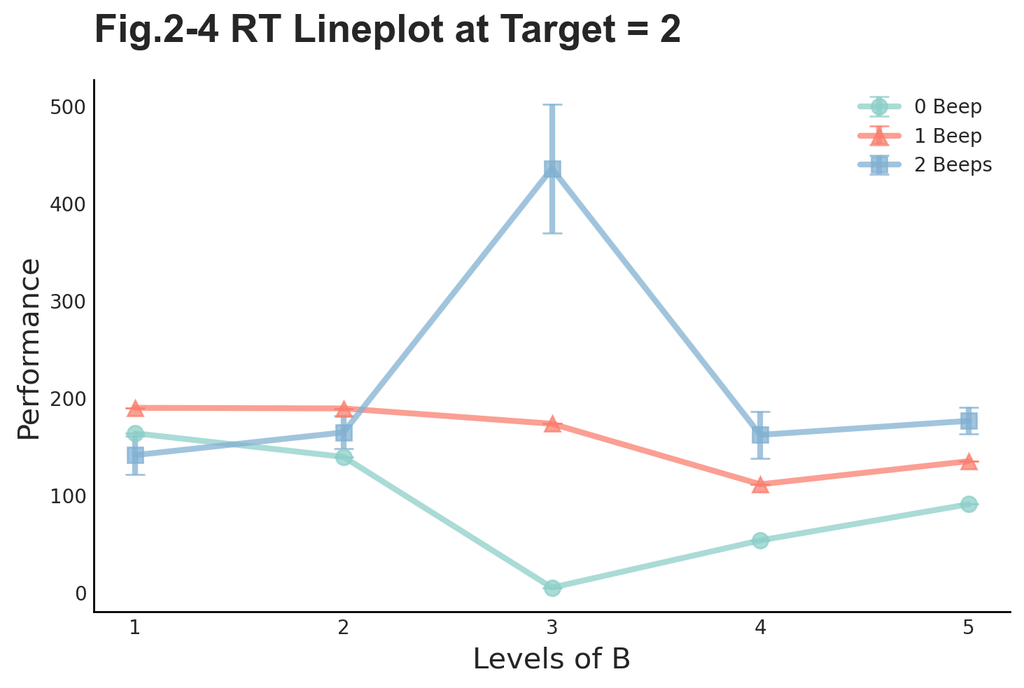

```python
## Draw plots at Target = 1

import numpy as np
import matplotlib.pyplot as plt
from scipy.stats import sem


data1 = T2B0_ecc_RT * 1000
data2 = T2B1_ecc_RT * 1000
data3 = T2B2_ecc_RT * 1000


x = np.arange(1, 6)
mean1 = np.mean(data1, axis=0)
stderr1 = sem(data1, axis=0)

mean2 = np.mean(data2, axis=0)
stderr2 = sem(data2, axis=0)

mean3 = np.mean(data3, axis=0)
stderr3 = sem(data3, axis=0)
plt.errorbar(x, mean1, yerr=stderr1, fmt='-o', label='0 Beep', capsize=5, color = gr, alpha = 0.75, linewidth = 3, markersize = 8)
plt.errorbar(x, mean2, yerr=stderr2, fmt='-^', label='1 Beep', capsize=5, color = re, alpha = 0.75, linewidth = 3, markersize = 8)
plt.errorbar(x, mean3, yerr=stderr3, fmt='-s', label='2 Beeps', capsize=5, color = bl, alpha = 0.75, linewidth = 3, markersize = 8)
plt.title('Fig.2-4 RT Lineplot at Target = 2', fontsize=20, fontweight='bold', y=1.05, fontfamily='Arial')
plt.xlabel('Levels of B')
plt.ylabel('Performance')
plt.xticks(x)
plt.legend(loc='best')
plt.show()
```

### Fig 3 Fission Illusion 探索（并未采用）

- 实验一里的fusion illusion并不突出，所以重点研究fission的效应。
- 重点研究F1B2的情况，比较不同SOA，position下的被试acc与RT。
- 由于不同的空间离心率下对视知觉敏锐度的影响，不同空间离心率的表现无法直接采用正确率比较；因此，引入 Fission Bias 对整合能力的强弱进行表征。

[figure not shown]

```python
# Demo of Fission Bias
data2 = T1B1_ecc
data3 = T1B2_ecc

x = np.arange(1, 6)
mean2 = np.mean(data2, axis=0)
stderr2 = sem(data2, axis=0)
mean3 = np.mean(data3, axis=0)
stderr3 = sem(data3, axis=0)

Fission_Bias = data2 - data3
mean_bias = np.mean(Fission_Bias, axis=0)
stderr_bias = sem(Fission_Bias, axis=0)


_,ax = plt.subplots(figsize=(8,4))


ax2 = ax.twinx()
ax.bar(x, mean_bias, yerr=stderr_bias, color = ak, alpha = 0.75, linewidth = 3, capsize=5, label='Fission Bias')
ax.set_ylim(0.00,0.35)
ax2.errorbar(x, mean2, yerr=stderr2, fmt='-^', label='0 B', capsize=5, color = re, alpha = 0.75, linewidth = 3, markersize = 8)
ax2.fill_between(x, mean2 - stderr2, mean2 + stderr2, color=re, alpha=0.3)
ax2.errorbar(x, mean3, yerr=stderr3, fmt='-s', label='2 B', capsize=5, color = bl, alpha = 0.75, linewidth = 3, markersize = 8)
ax2.fill_between(x, mean3 - stderr3, mean3 + stderr3, color=bl, alpha=0.3)
ax2.spines['right'].set_visible(True)
ax2.set_ylim(0.65,1.0)

plt.title('Fig.3 Fission Bias Demo', fontsize=20, fontweight='bold', y=1.05, fontfamily='Arial')
plt.xlabel('')
plt.ylabel('')
plt.xticks(x, ['-21°', '-7°', '0°', '7°', '21°'], fontsize=15)
plt.legend(loc='best')
plt.show()
```

```python
FI_Ecc1 = np.zeros((use_num, 6))
FI_Ecc2 = np.zeros((use_num, 6))
FI_Ecc3 = np.zeros((use_num, 6))
FI_Ecc4 = np.zeros((use_num, 6))
FI_Ecc5 = np.zeros((use_num, 6))

import matplotlib.pyplot as plt
from scipy.stats import sem

for i in range(1, use_num+1):
    currentdata = pd.read_excel('DFI_1_Data.xlsx',sheet_name='Sheet'+str(i))
    dt = currentdata.copy()

    T1B0 = dt[(dt['TargetNum'] == 1) & (dt['InducerNum'] == 0)]
    T1B1 = dt[(dt['TargetNum'] == 1) & (dt['InducerNum'] == 1)]
    T1B2 = dt[(dt['TargetNum'] == 1) & (dt['InducerNum'] == 2)]

    for ecc in range(1,6):
        FI_Ecc1[i-1, :] = T1B2[T1B2['TargetPos'] == 1]['mean_RespAcc'].values
        FI_Ecc2[i-1, :] = T1B2[T1B2['TargetPos'] == 2]['mean_RespAcc'].values
        FI_Ecc3[i-1, :] = T1B2[T1B2['TargetPos'] == 3]['mean_RespAcc'].values
        FI_Ecc4[i-1, :] = T1B2[T1B2['TargetPos'] == 4]['mean_RespAcc'].values
        FI_Ecc5[i-1, :] = T1B2[T1B2['TargetPos'] == 5]['mean_RespAcc'].values

# combine into a dataframe
FI_Ecc1 = pd.DataFrame(FI_Ecc1, columns=['-120', '-70', '-30', '30', '70', '120'])
FI_Ecc1['Eccentricity'] = '-21°'
FI_Ecc2 = pd.DataFrame(FI_Ecc2, columns=['-120', '-70', '-30', '30', '70', '120'])
FI_Ecc2['Eccentricity'] = '-7°'
FI_Ecc3 = pd.DataFrame(FI_Ecc3, columns=['-120', '-70', '-30', '30', '70', '120'])
FI_Ecc4 = pd.DataFrame(FI_Ecc4, columns=['-120', '-70', '-30', '30', '70', '120'])
FI_Ecc5 = pd.DataFrame(FI_Ecc5, columns=['-120', '-70', '-30', '30', '70', '120'])

FI_Ecc3['Eccentricity'] = '0°'
FI_Ecc4['Eccentricity'] = '7°'
FI_Ecc5['Eccentricity'] = '21°'

FI_combined = pd.concat([FI_Ecc1, FI_Ecc2, FI_Ecc3, FI_Ecc4, FI_Ecc5])
subjects_repeated = np.tile(np.arange(1, 10), 5)
FI_combined['Subjects'] = subjects_repeated

FI_melted = FI_combined.melt(id_vars=['Eccentricity','Subjects'], var_name='SOA', value_name='Accuracy')
FI_pivot = FI_melted.pivot(columns=['Eccentricity','SOA'], values='Accuracy', index='Subjects')
FI_pivot.columns = [f'{col[0]}_{col[1]}' for col in FI_pivot.columns]
# FI_pivot.to_csv('Exp_3_1013.csv', index=False)
```

### Fig 4 SOA和空间离心度的交互影响

现在来考虑SOA的影响，分别绘制Accuracy和SOA的关系与Fission Bias和SOA的关系。

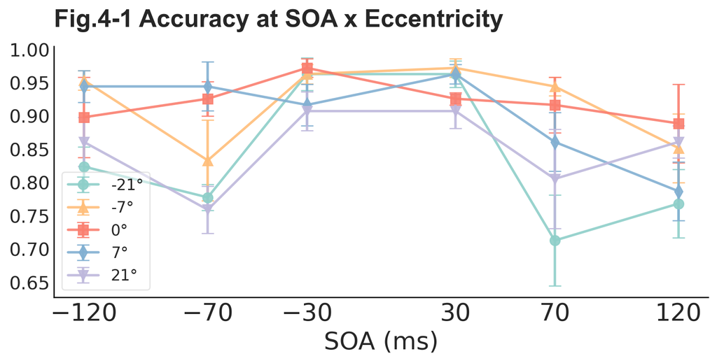

```python
FI_Ecc1 = np.zeros((use_num, 6))
FI_Ecc2 = np.zeros((use_num, 6))
FI_Ecc3 = np.zeros((use_num, 6))
FI_Ecc4 = np.zeros((use_num, 6))
FI_Ecc5 = np.zeros((use_num, 6))
F1B2_30ms = np.zeros((use_num, 5))
F1B2__30ms = np.zeros((use_num, 5))
import matplotlib.pyplot as plt
from scipy.stats import sem

for i in range(1, use_num+1):
    currentdata = pd.read_excel('DFI_1_Data.xlsx',sheet_name='Sheet'+str(i))
    dt = currentdata.copy()

    T1B0 = dt[(dt['TargetNum'] == 1) & (dt['InducerNum'] == 0)]
    T1B1 = dt[(dt['TargetNum'] == 1) & (dt['InducerNum'] == 1)]
    T1B2 = dt[(dt['TargetNum'] == 1) & (dt['InducerNum'] == 2)]
    F1B2_30ms[i-1,:] = T1B2[T1B2['SOA'] == 30]['mean_RespAcc'].values
    F1B2__30ms[i-1,:] = T1B2[T1B2['SOA'] == -30]['mean_RespAcc'].values

    for ecc in range(1,6):
        FI_Ecc1[i-1, :] = T1B2[T1B2['TargetPos'] == 1]['mean_RespAcc'].values
        FI_Ecc2[i-1, :] = T1B2[T1B2['TargetPos'] == 2]['mean_RespAcc'].values
        FI_Ecc3[i-1, :] = T1B2[T1B2['TargetPos'] == 3]['mean_RespAcc'].values
        FI_Ecc4[i-1, :] = T1B2[T1B2['TargetPos'] == 4]['mean_RespAcc'].values
        FI_Ecc5[i-1, :] = T1B2[T1B2['TargetPos'] == 5]['mean_RespAcc'].values

fig = plt.figure(figsize=(8,4))
color_lst = [gr,ye,re,bl,pu]
fmt_lst = ['-o', '-^', '-s', '-d', '-v']
x_SOA = [-120, -70, -30, 30, 70, 120]
Eccentricity = ['-21°', '-7°', '0°', '7°', '21°']
for pos in range(5):
    exec('FI_data = FI_Ecc' + str(pos+1))
    data_mean = np.mean(FI_data, axis=0)
    data_stderr = sem(FI_data, axis=0)
    plt.errorbar(x_SOA, data_mean, yerr=data_stderr, fmt= fmt_lst[pos], label=str(Eccentricity[pos]), capsize=5, color = color_lst[pos], alpha = 0.9, linewidth = 2, markersize = 8)
plt.title('Fig.4-1 Accuracy at SOA x Eccentricity', fontsize=20, fontweight='bold', y=1.05, fontfamily='Arial')
plt.xlabel('SOA (ms)',fontsize = 20)
plt.ylabel('')
plt.xticks(x_SOA,fontsize=20)
plt.legend(loc='lower left', title='', fontsize='small', frameon=True, framealpha=0.5, fancybox=True)
plt.yticks(fontsize = 15)
plt.show()
```

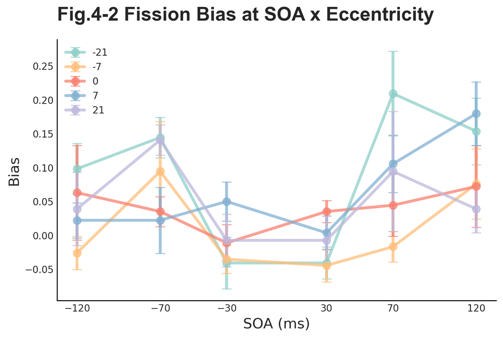

```python
color_lst = [gr,ye,re,bl,pu]

x_SOA = [-120, -70, -30, 30, 70, 120]
Eccentricity = [-21, -7, 0, 7, 21]
for pos in range(5):
    FI_data = eval('FI_Ecc' + str(pos+1))
    T1B0_ecc_repmat = np.tile(T1B0_ecc[:,pos], (6,1)).T # repmat T1B1_ecc[:,pos+1] to fit the size of FI_data
    FI_Bias = T1B0_ecc_repmat - FI_data
    data_mean = np.mean(FI_Bias, axis=0)
    data_stderr = sem(FI_Bias, axis=0)

    plt.errorbar(x_SOA, data_mean, yerr=data_stderr, fmt='-o', label=str(Eccentricity[pos]), capsize=5, color = color_lst[pos], alpha = 0.75, linewidth = 3, markersize = 8)

plt.title('Fig.4-2 Fission Bias at SOA x Eccentricity', fontsize=20, fontweight='bold', y=1.05, fontfamily='Arial')
plt.xlabel('SOA (ms)')
plt.ylabel('Bias')
plt.xticks(x_SOA)
plt.legend(loc='best')
plt.show()
```

### Fig 5 拟合SOA正态曲线并比较width （FWHM） 与 amplitude （未采用）

因为在-30ms和30ms的数据可能收到声音播放设备的限制，并没有很好地引起SIFI，所以在拟合数据点时将其暂时去掉。

```
For A level 1, Amplitude=0.29, FWHM=331.41
For A level 2, Amplitude=0.11, FWHM=712.56
Could not fit data for A level 3
Could not fit data for A level 4
For A level 5, Amplitude=0.28, FWHM=239.01
```

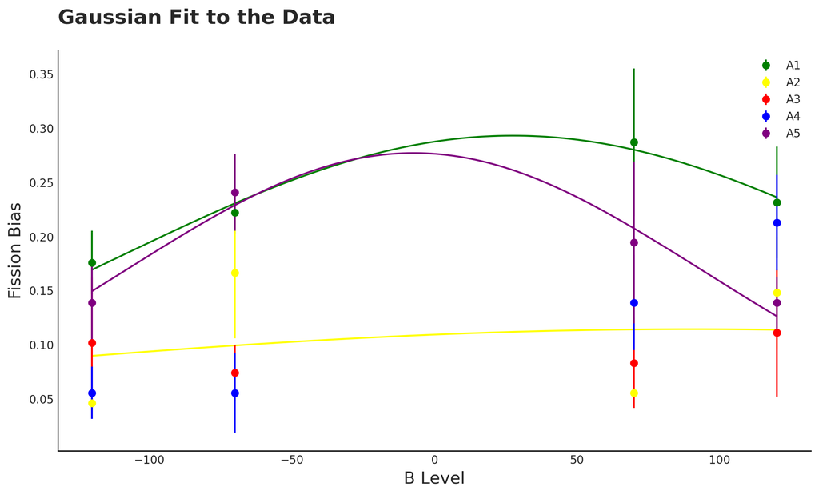

```python
import numpy as np
import matplotlib.pyplot as plt
from scipy.optimize import curve_fit
from scipy.stats import sem

def gaussian(x, A, mu, sigma):
    return A * np.exp(-0.5 * ((x - mu) / sigma) ** 2)

# the format of data should be like this:
data = np.random.rand(8, 4)
x = np.array([-120, -70, 70, 120])

plt.figure(figsize=(10, 6))
colors = ['green', 'yellow', 'red', 'blue', 'purple']

for pos in range(5):  # 5 eccs

    exec('FI_data = FI_Ecc' + str(pos+1))
    FI_data = 1 - FI_data[:, [0, 1, 4, 5]]

    mean = np.mean(FI_data, axis=0)
    stderr = sem(FI_data, axis=0)

    # define initial guesses for the parameters
    A_guess = np.max(mean)
    mu_guess = x[np.argmax(mean)]
    sigma_guess = (x[-1] - x[0]) / 4
    p0 = [A_guess, mu_guess, sigma_guess]
    plt.errorbar(x, mean, yerr=stderr, fmt='o', color=colors[pos], label=f'A{pos+1}')
    # fit the data to the Gaussian function
    try:
        popt, pcov = curve_fit(gaussian, x, mean, p0=p0, maxfev=10000)

        # extract the fitted parameters
        A_fit, mu_fit, sigma_fit = popt

        # calculate the FWHM
        FWHM = 2.35482 * sigma_fit

        print(f"For A level {pos+1}, Amplitude={A_fit:.2f}, FWHM={FWHM:.2f}")

        x_fit = np.linspace(min(x), max(x), 1000)
        y_fit = gaussian(x_fit, A_fit, mu_fit, sigma_fit)
        plt.plot(x_fit, y_fit, color=colors[pos])
    except RuntimeError:
        print(f"Could not fit data for A level {pos+1}")

plt.title('Gaussian Fit to the Data')
plt.xlabel('B Level')
plt.ylabel('Fission Bias')
plt.legend(loc='best')

plt.show()
```

如果使用Fission Bias拟合：

```
For A level 1, Amplitude=0.22, FWHM=264.61
For A level 2, Amplitude=0.13, FWHM=20.89
Could not fit data for A level 3
Could not fit data for A level 4
For A level 5, Amplitude=0.22, FWHM=148.00
```

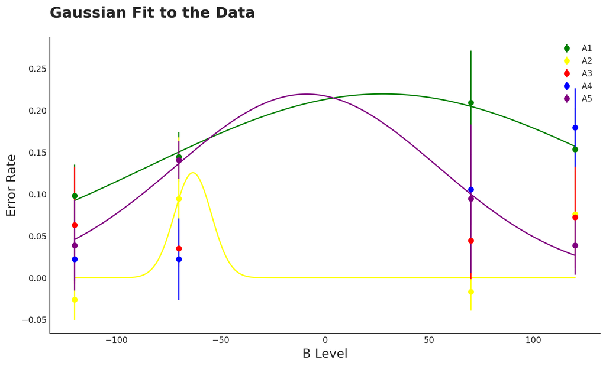

```python
# the format of data should be like this:
data = np.random.rand(8, 4)
x = np.array([-120, -70, 70, 120])

plt.figure(figsize=(10, 6))
colors = ['green', 'yellow', 'red', 'blue', 'purple']

for pos in range(5):  # 5 eccs
    exec('FI_data = FI_Ecc' + str(pos+1))
    T1B0_ecc_repmat = np.tile(T1B0_ecc[:,pos], (6,1)).T # repmat T1B1_ecc[:,pos+1] to fit the size of FI_data
    FI_Bias = T1B0_ecc_repmat - FI_data
    FI_Bias = FI_Bias[:, [0, 1, 4, 5]]

    mean = np.mean(FI_Bias, axis=0)
    stderr = sem(FI_Bias, axis=0)

    # define initial guesses for the parameters
    A_guess = np.max(mean)
    mu_guess = x[np.argmax(mean)]
    sigma_guess = (x[-1] - x[0]) / 4
    p0 = [A_guess, mu_guess, sigma_guess]
    plt.errorbar(x, mean, yerr=stderr, fmt='o', color=colors[pos], label=f'A{pos+1}')
    # fit the data to the Gaussian function
    try:
        popt, pcov = curve_fit(gaussian, x, mean, p0=p0, maxfev=10000)

        # extract the fitted parameters
        A_fit, mu_fit, sigma_fit = popt

        # calculate the FWHM
        FWHM = 2.35482 * sigma_fit

        print(f"For A level {pos+1}, Amplitude={A_fit:.2f}, FWHM={FWHM:.2f}")

        x_fit = np.linspace(min(x), max(x), 1000)
        y_fit = gaussian(x_fit, A_fit, mu_fit, sigma_fit)
        plt.plot(x_fit, y_fit, color=colors[pos])
    except RuntimeError:
        print(f"Could not fit data for A level {pos+1}")

plt.title('Gaussian Fit to the Data')
plt.xlabel('B Level')
plt.ylabel('Error Rate')
plt.legend(loc='best')

plt.show()
```

拟合离心率正态曲线并比较width （FWHM） 与 amplitude

```
For A level 5, Amplitude=0.92, FWHM=117.45
R-squared value: 0.97
For A level 5, Amplitude=0.94, FWHM=192.74
```

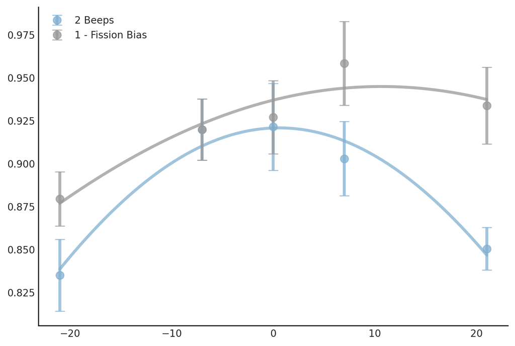

```
R-squared value: 0.90
```

```python
currentdata = T1B2_ecc

mean = np.mean(currentdata, axis=0)
stderr = sem(currentdata, axis=0)
x = [-21, -7, 0, 7, 21]
# define initial guesses for the parameters
A_guess = np.max(mean)
mu_guess = x[np.argmax(mean)]
sigma_guess = (x[-1] - x[0]) / 4
p0 = [A_guess, mu_guess, sigma_guess]
plt.errorbar(x, mean, yerr=stderr, fmt='o', label='2 Beeps', capsize=5, color = bl, alpha = 0.75, linewidth = 3, markersize = 8)
# fit the data to the Gaussian function

popt, pcov = curve_fit(gaussian, x, mean, p0=p0, maxfev=10000)

# extract the fitted parameters
A_fit, mu_fit, sigma_fit = popt

# calculate the FWHM
FWHM = 2.35482 * sigma_fit

print(f"For A level {pos+1}, Amplitude={A_fit:.2f}, FWHM={FWHM:.2f}")

x_fit = np.linspace(min(x), max(x), 1000)
y_fit = gaussian(x_fit, A_fit, mu_fit, sigma_fit)
plt.plot(x_fit, y_fit, color = bl, alpha = 0.75, linewidth = 3, markersize = 0)


# calculate the residuals
residuals = mean - gaussian(x, A_fit, mu_fit, sigma_fit)

# calculate the total sum of squares
tss = np.sum((mean - np.mean(mean)) ** 2)

# calculate the sum of squared residuals
ssr = np.sum(residuals ** 2)

# calculate the R-squared value
r_squared = 1 - (ssr / tss)

print(f"R-squared value: {r_squared:.2f}")

currentdata = 1-Fission_Bias

mean = np.mean(currentdata, axis=0)
stderr = sem(currentdata, axis=0)
x = [-21, -7, 0, 7, 21]
# define initial guesses for the parameters
A_guess = np.max(mean)
mu_guess = x[np.argmax(mean)]
sigma_guess = (x[-1] - x[0]) / 4
p0 = [A_guess, mu_guess, sigma_guess]
plt.errorbar(x, mean, yerr=stderr, fmt='o', label='1 - Fission Bias', capsize=5, color = ak, alpha = 0.75, linewidth = 3, markersize = 8)
# fit the data to the Gaussian function

popt, pcov = curve_fit(gaussian, x, mean, p0=p0, maxfev=10000)

# extract the fitted parameters
A_fit, mu_fit, sigma_fit = popt

# calculate the FWHM
FWHM = 2.35482 * sigma_fit

print(f"For A level {pos+1}, Amplitude={A_fit:.2f}, FWHM={FWHM:.2f}")

x_fit = np.linspace(min(x), max(x), 1000)
y_fit = gaussian(x_fit, A_fit, mu_fit, sigma_fit)
plt.plot(x_fit, y_fit, color = ak, alpha = 0.75, linewidth = 3, markersize = 0)

plt.legend(loc='best')
plt.show()

# calculate the residuals
residuals = mean - gaussian(x, A_fit, mu_fit, sigma_fit)

# calculate the total sum of squares
tss = np.sum((mean - np.mean(mean)) ** 2)

# calculate the sum of squared residuals
ssr = np.sum(residuals ** 2)

# calculate the R-squared value
r_squared = 1 - (ssr / tss)

print(f"R-squared value: {r_squared:.2f}")
```

将所有的分析、变量保存在db文件中，后续直接导入即可

```python
import dill
dill.dump_session('DFI_1_Data.db')
```